# AtlasVPM: Atlas de Farmacia

Variaciones en el consumo de **Antidepresivos** por Zona Básica de Salud

Autor/a

Afiliaciones

[Atlas de Variaciones injustificadas de la Práctica Médica (Atlas VPM)](https://cienciadedatosysalud.org/)

Grupo de Ciencia de datos para la investigación en servicios y políticas sanitarias

Instituto Aragonés de Ciencias de la Salud (IACS)

Red de Investigación en Cronicidad, Atención Primaria y Prevención y Promoción de la Salud (RICAPPS)

Fecha de publicación

24 de noviembre de 2026

Versión de los análisis: 0.0.1

# Resumen ejecutivo

El número de envases de antidepresivos dispensados en el periodo 2017-2024 aumentó un 45,4% (de 11,4 millones a 16,6 millones de dispensaciones). El 72,5% de todas estas dispensaciones se realizaron en mujeres. El porcentaje de mujeres con alguna dispensación de antidepresivos fue mayor en todos los tramos etarios exceptuando a la población pediátrica. Las tarjetas sanitarias sin aseguramiento, farmacia gratuita y pensionistas y activos con rentas inferiores a 18000 euros (64,3% de la población en las CCAA analizadas) recibieron aproximadamente el 74,3% de los envases dispensados de antidepresivos.

Con variación en la evolución anual y entre CCAA, en torno al 47% de los envases dispensados correspondieron a otros antidepresivos, el 44% a inhibidores selectivos de recaptación de serotonina, y cerca del 9% a inhibidores no selectivos de recaptación de monoaminas.

La mediana de consumo de antidepresivos seleccionados en términos de DHD aumentó para el conjunto de ZBS pasando de 64,71 DHD en 2017 a 88,35 DHD en 2024 (aumento del 36,5%). Con variaciones entre las CCAA analizadas, analizando por subgrupos, se produjo un aumento en todos ellos, con el mayor aumento relativo en otros antidepresivos (57,2%), seguido de inhibidores no selectivos de recaptación de monoaminas (25%) y finalmente inhibidores selectivos de recaptación de serotonina (23,9%).

Para el conjunto de antidepresivos analizados y años, la variación de DHD entre las ZBS de más y menos consumo, sin considerar las ZBS con valores extremos, fue de una razón de variación de 2,6 veces las DHD entre estas ZBS, siendo esta variación constante a lo largo de los años. Por subgrupos terapéuticos, esta variación fue más elevada, siendo mayor en inhibidores no selectivos de recaptación de monoaminas con una razón de variación de 3,8 veces entre las ZBS de más y menos consumo, otros antidepresivos con una razón de 3,3, y inhibidores selectivos de recaptación de serotonina con una razón de 2,6.

# Contexto

Este informe pertenece a la serie de informes de AtlasVPM sobre Farmacia, en el que se incluyen el análisis de consumo de Antidepresivos y de Antipsicóticos. En este informe nos referimos a consumo como la dispensación ambulatoria de un fármaco en oficina de farmacia a una persona con tarjeta sanitaria en el Sistema Nacional de Salud (SNS). El consumo de los medicamentos está mediado por la prescripción de un profesional sanitario -principalmente los médicos especialistas en medicina familiar y comunitaria- y, en el caso de algunos medicamentos, al visado de la receta médica por un inspector del SNS. La utilización de los medicamentos, como sucede con otras tecnologías sanitarias, está sujeta a una gran variabilidad. El análisis de las *variaciones en la práctica médica*, entendidas como las variaciones sistemáticas -no aleatorias- en las tasas estandarizadas de una exposición o intervención sanitaria (i.e., consumo de medicamento) al nivel que se produce la toma de decisiones sobre esta exposición o intervención sanitaria, en este caso, a nivel de Zona Básica de Salud (ZBS), es indispensable para identificar potenciales problemas de gestión sanitaria y ayudar a orientar la toma de decisiones sobre los servicios de salud. Las variaciones sistemáticas en los patrones de dispensación de medicamentos antidepresivos y antipsicóticos suponen un desafío importante para todos los Sistemas de Salud.

**Atención**

Debe tenerse en cuenta que, cuando se habla de grupos mayores (N06AA, N06AAB, N06AX) o total (N06A) de Antidepresivos en este estudio, estos ATC no incluyen todos los antidepresivos sino sólo aquellos seleccionados como relevantes para estudio que aparecen en Sección 4.3 (para más información descargar el fichero ([Modelo de datos](https://github.com/cienciadedatosysalud/atlas-farmacia/blob/main/atlas_antidepresivos/docs/CDM/common_datamodel.xlsx))

# Resultados

En este estudio participan un total de 8 comunidades autónomas, con una población global de 16,312,282 en el año 2024, de la cual, la media mensual de personas distintas que han sido dispensadas de algún antidepresivo (ATC = N06A) durante el periodo de estudio 2017 a 2024 es de un 6.38%.

**Descripción tabla**

La siguiente tabla muestra el número de envases totales por año, la aportación al mismo por cada comunidad autónoma, sexo y para el conjunto específico de categorías TSI (0,1,2, y 4).

Tabla descriptiva anual: Nº envases (%)

Antidepresivos (N06A)

|  | 2017 | 2018 | 2019 | 2020 | 2021 | 2022 | 2023 | 2024 |
| --- | --- | --- | --- | --- | --- | --- | --- | --- |
| Total Nº envases anual |  |  |  |  |  |  |  |  |
| Nº envases | 11417703 | 12125633 | 12757468 | 13329811 | 14124114 | 15038801 | 15737561 | 16595823 |
| CCAA |  |  |  |  |  |  |  |  |
| Asturias | 1241046 (10.87%) | 1283370 (10.58%) | 1331597 (10.44%) | 1385458 (10.39%) | 1447383 (10.25%) | 1523075 (10.13%) | 1574915 (10.01%) | 1641878 (9.89%) |
| País Vasco | 1578454 (13.82%) | 1693496 (13.97%) | 1762143 (13.81%) | 1832170 (13.74%) | 1922076 (13.61%) | 2010839 (13.37%) | 2126946 (13.52%) | 2217786 (13.36%) |
| Navarra | 405897 (3.55%) | 438323 (3.61%) | 450142 (3.53%) | 461360 (3.46%) | 477806 (3.38%) | 492455 (3.27%) | 509415 (3.24%) | 526085 (3.17%) |
| La Rioja | 231288 (2.03%) | 241581 (1.99%) | 252836 (1.98%) | 267326 (2.01%) | 280712 (1.99%) | 295744 (1.97%) | 305866 (1.94%) | 312433 (1.88%) |
| Aragón | 1117421 (9.79%) | 1174423 (9.69%) | 1234868 (9.68%) | 1315431 (9.87%) | 1401331 (9.92%) | 1486674 (9.89%) | 1541553 (9.8%) | 1603860 (9.66%) |
| Madrid | 3660211 (32.06%) | 3956899 (32.63%) | 4238694 (33.23%) | 4380995 (32.87%) | 4671058 (33.07%) | 5067963 (33.7%) | 5319044 (33.8%) | 5699062 (34.34%) |
| Castilla y León | 1974844 (17.3%) | 2048240 (16.89%) | 2114931 (16.58%) | 2188248 (16.42%) | 2283666 (16.17%) | 2392118 (15.91%) | 2477268 (15.74%) | 2584276 (15.57%) |
| Región de Murcia | 1208542 (10.58%) | 1289301 (10.63%) | 1372257 (10.76%) | 1498823 (11.24%) | 1640082 (11.61%) | 1769933 (11.77%) | 1882554 (11.96%) | 2010443 (12.11%) |
| Sexo |  |  |  |  |  |  |  |  |
| Hombres | 3088406 (27.05%) | 3297276 (27.19%) | 3492080 (27.37%) | 3640917 (27.31%) | 3855867 (27.3%) | 4132465 (27.48%) | 4372073 (27.78%) | 4658401 (28.07%) |
| Mujeres | 8329297 (72.95%) | 8828357 (72.81%) | 9265388 (72.63%) | 9688894 (72.69%) | 10268247 (72.7%) | 10906336 (72.52%) | 11365488 (72.22%) | 11937422 (71.93%) |
| Conjunto categorías TSI < 18.000 € (Categorías 0, 1, 2, 4) |  |  |  |  |  |  |  |  |
| Conjunto categorías TSI < 18.000 € (Categorías 0, 1, 2, 4) | 8903832 (77.98%) | 9439231 (77.85%) | 10025348 (78.58%) | 10007495 (75.08%) | 10452645 (74.01%) | 11018718 (73.27%) | 11196535 (71.15%) | 11482659 (69.19%) |

## Porcentaje de envases dispensados por subgrupo terapéutico

**Descripción figura**

Para el total de envases dispensados (suma de todas las comunidades autónomas participantes) en toda la serie temporal, se muestra el porcentaje de envases por cada subgrupo terapéutico.

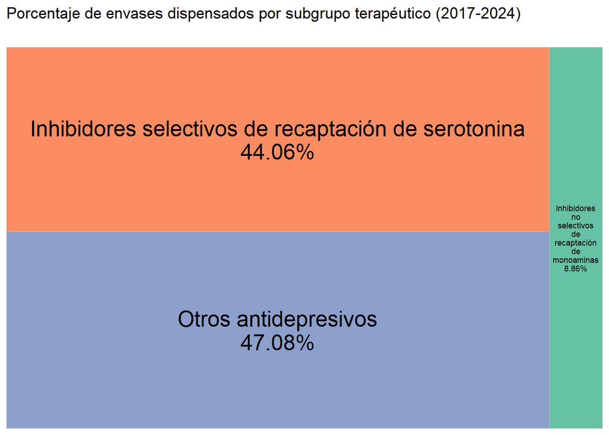

## Evolución temporal del porcentaje de envases dispensados por subgrupo terapéutico

**Descripción figura**

Para el total de envases dispensados en toda la serie temporal en cada comunidad autónoma, se muestra el porcentaje de envases por cada subgrupo terapéutico.

La leyenda es, de acuerdo con la figura anterior,:

- Inhibidores no selectivos de recaptación de monoaminas (N06AA),
- Inhibidores selectivos de recaptación de serotonina (N06AB),
- Otros antidepresivos (N06AX),

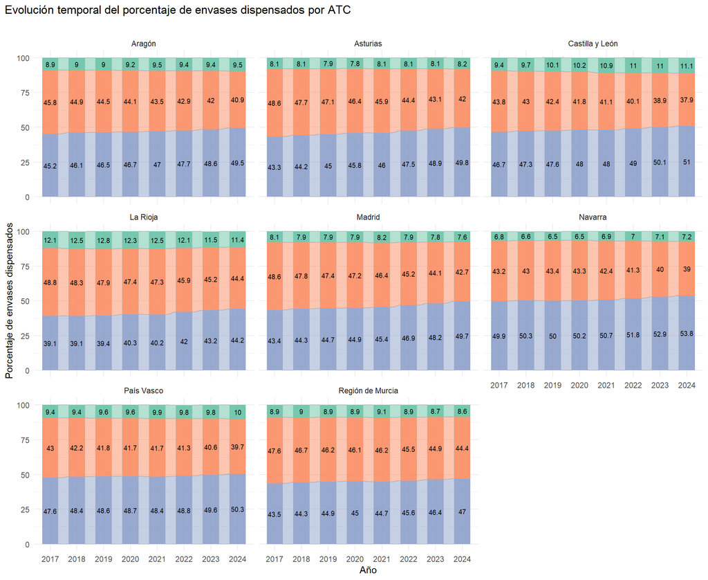

## Distribución de la población con alguna dispensación de antidepresivos (*N06A*) por grupo de edad y sexo

**Descripción figura**

Se muestra la distribución de la población con dispensaciones por grupo quinquenal de edad y sexo en toda la serie temporal.

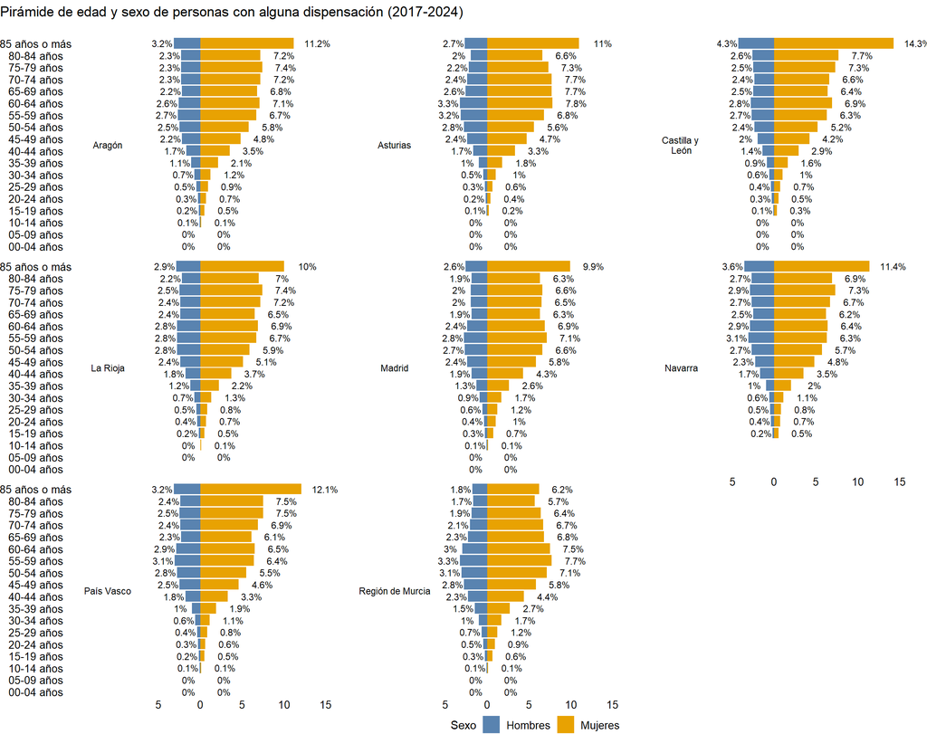

## Porcentaje de población con alguna dispensación de antidepresivos (*N06A*) en cada mes para el conjunto de la serie temporal y por sexo

**Descripción figura**

Se muestra la distribución de la población con dispensaciones por sexo y mes en toda la serie temporal. Se construye calculando el porcentaje de personas con alguna dispensación por sexo para cada mes de cada año y luego realizando la media de cada mes a lo largo de la serie temporal.

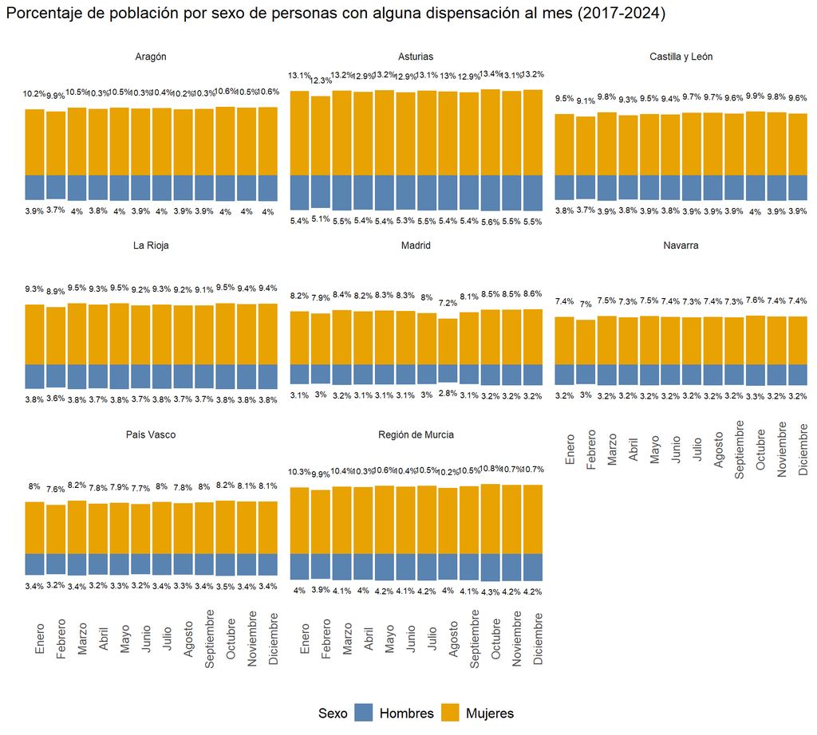

## Evolución de la variación de consumo por ZBS (SNS)

**Descripción figura**

Se muestra la variación (mediante violines) del consumo (DHD) en las zonas básicas de salud que componen el sistema nacional de salud de manera que cada punto es una zona básica. Las líneas discontinuas negras son la mediana (P50) anual y la línea discontinua roja (P50 global) es la mediana de toda la serie temporal.

**Antidepresivos (N06A)**

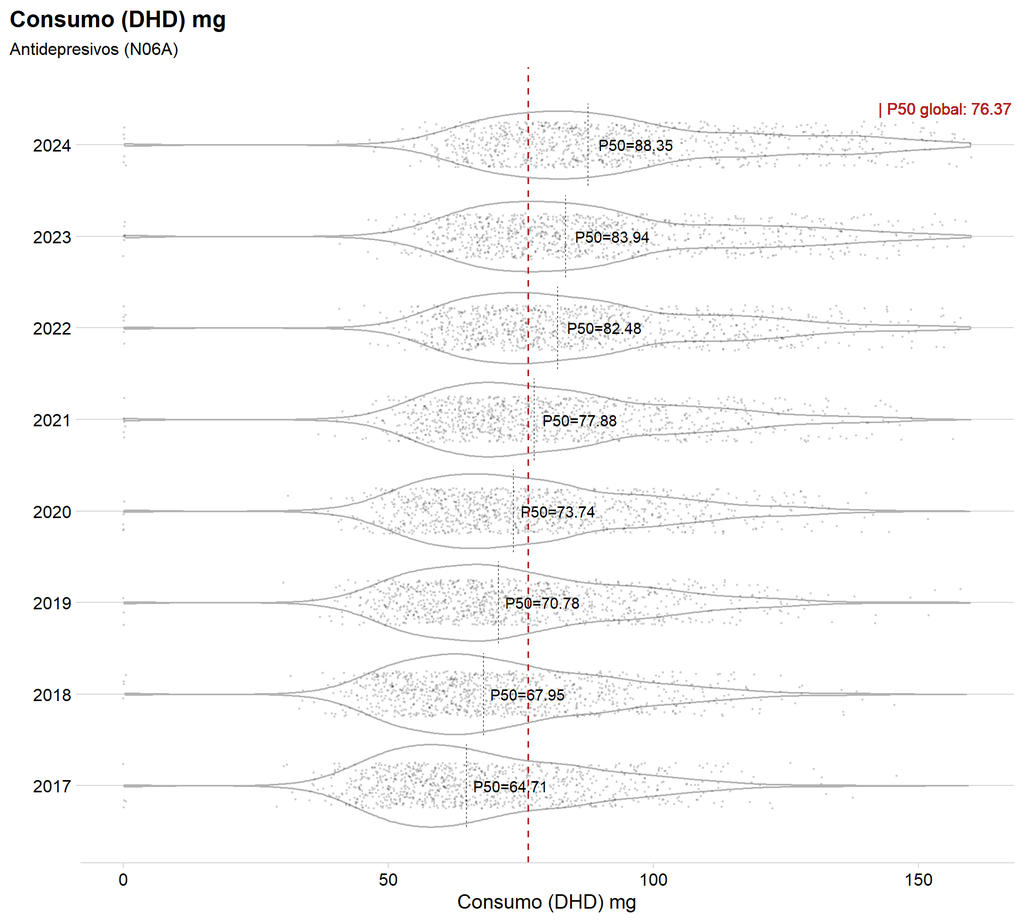

**Inhibidores no selectivos de recaptación de monoaminas (N06AA)**

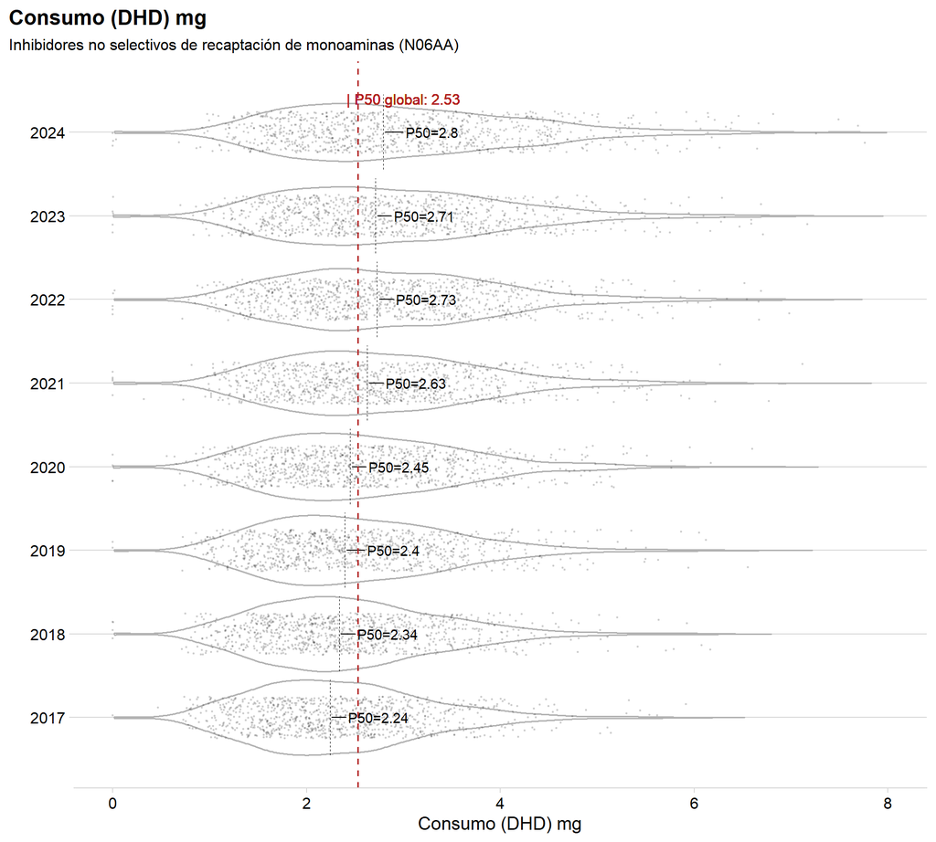

**Inhibidores selectivos de recaptación de serotonina (N06AB)**

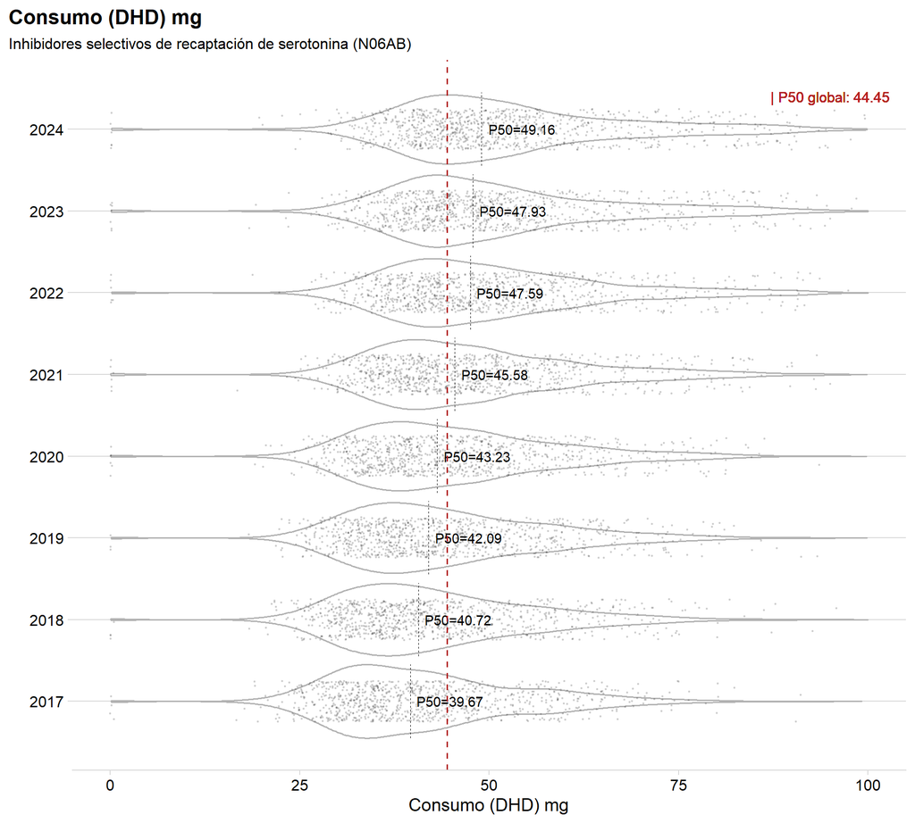

**Otros antidepresivos (N06AX)**

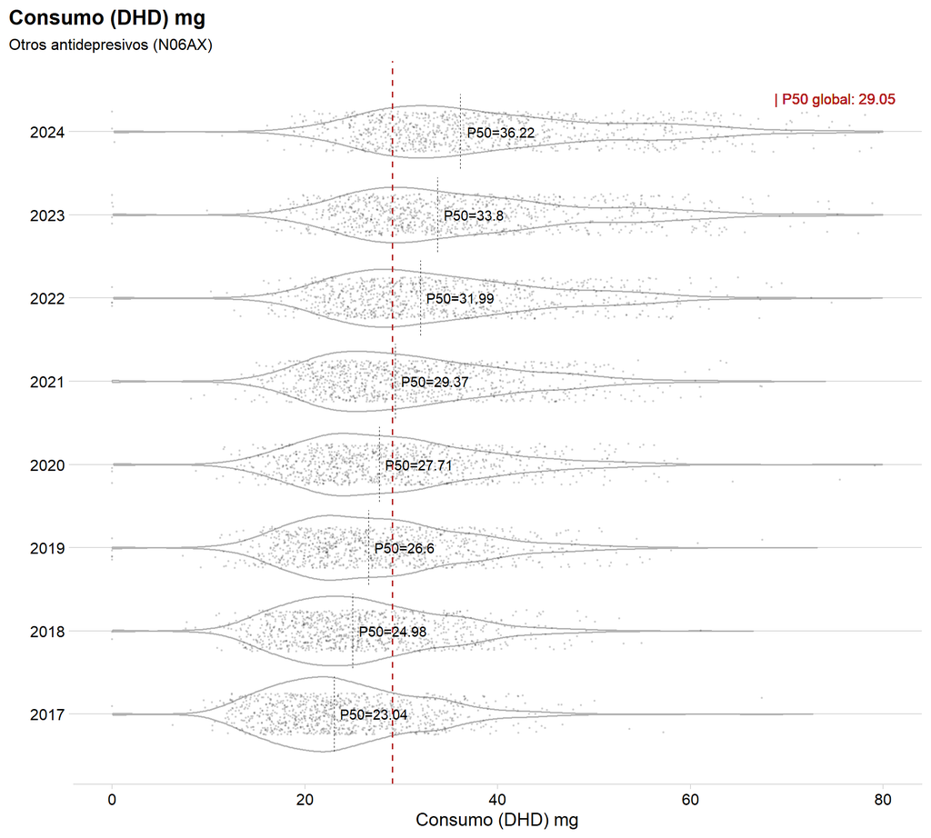

## Evolución de la variación de consumo por ZBS y TSI (SNS)

**Descripción figura**

Se muestra la variación (mediante violines) del consumo (DHD) en las zonas básicas de salud que componen el sistema nacional de salud de manera que cada punto es una zona básica. Las líneas discontinuas negras son la mediana (P50) anual y la línea discontinua roja (P50 global) es la mediana de toda la serie temporal. Se comparan: categorías TSI < 18.000 € vs categorías TSI >= 18.000 €.

**Antidepresivos (N06A)**

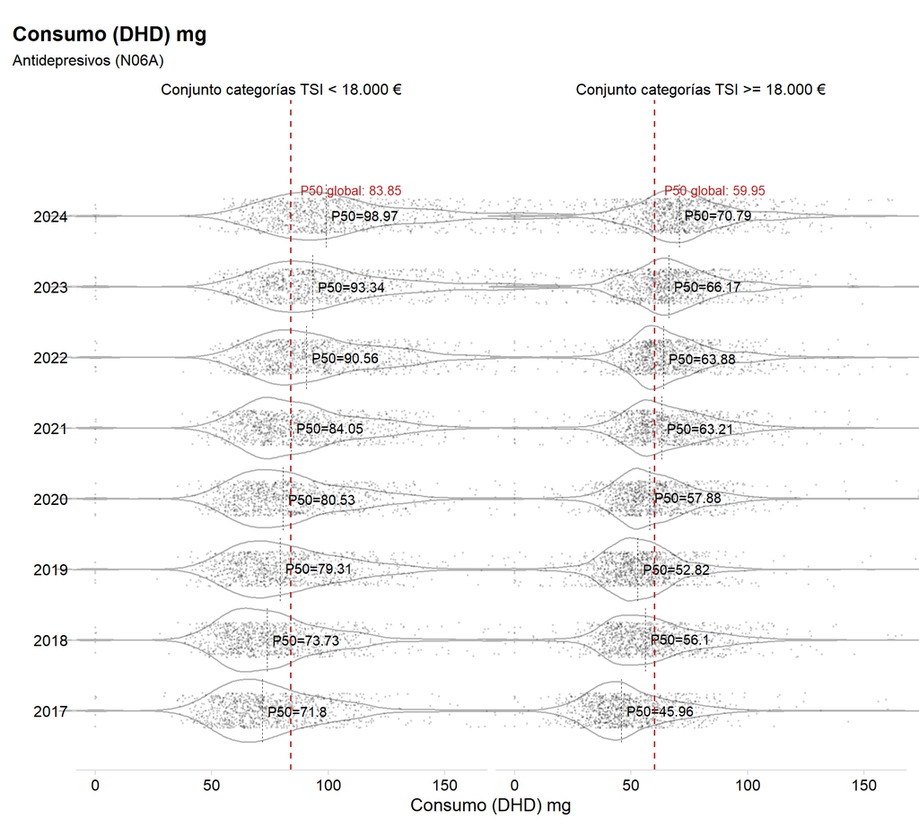

**Inhibidores no selectivos de recaptación de monoaminas (N06AA)**

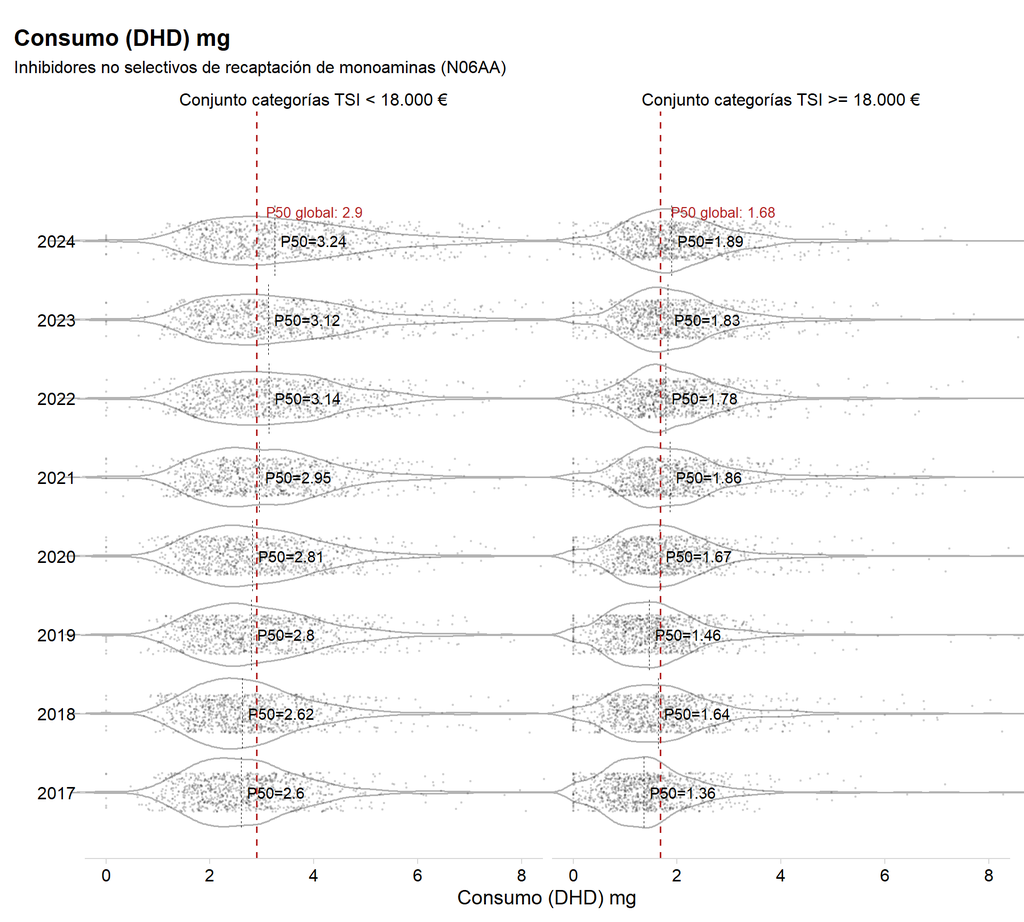

**Inhibidores selectivos de recaptación de serotonina (N06AB)**

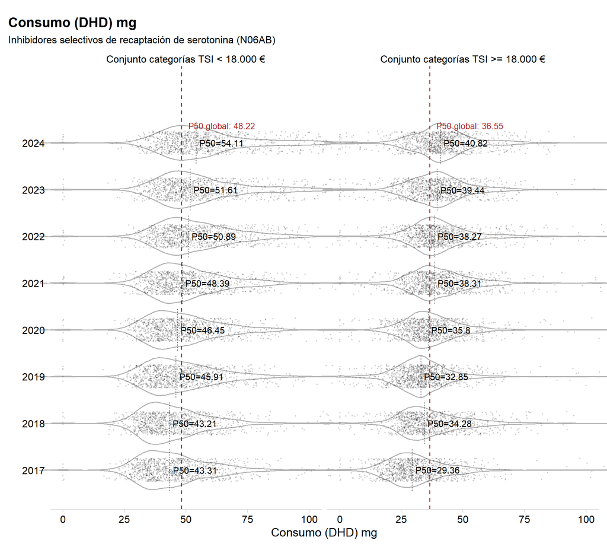

**Otros antidepresivos (N06AX)**

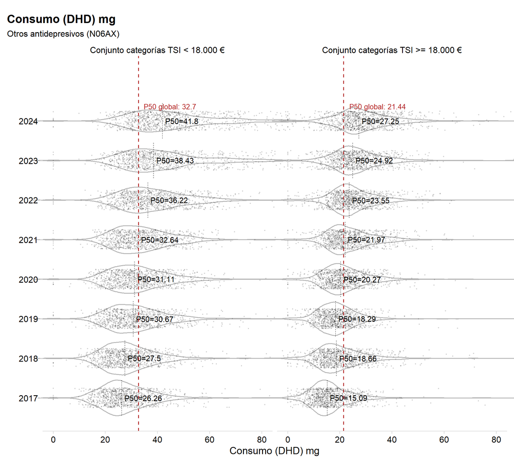

## Evolución de la variación de consumo (DHD) por ZBS y por CCAA

**Descripción figura**

Se muestra la evolución de la variación por CCAA del consumo (DHD) en las zonas básicas de salud que componen el sistema nacional de salud de manera que cada punto es una zona básica. La línea sólida roja es la mediana nacional y la zona sobreada gris es el rango intercuartílico, por lo que son comunes a todas las comunidades.

**Antidepresivos (N06A)**

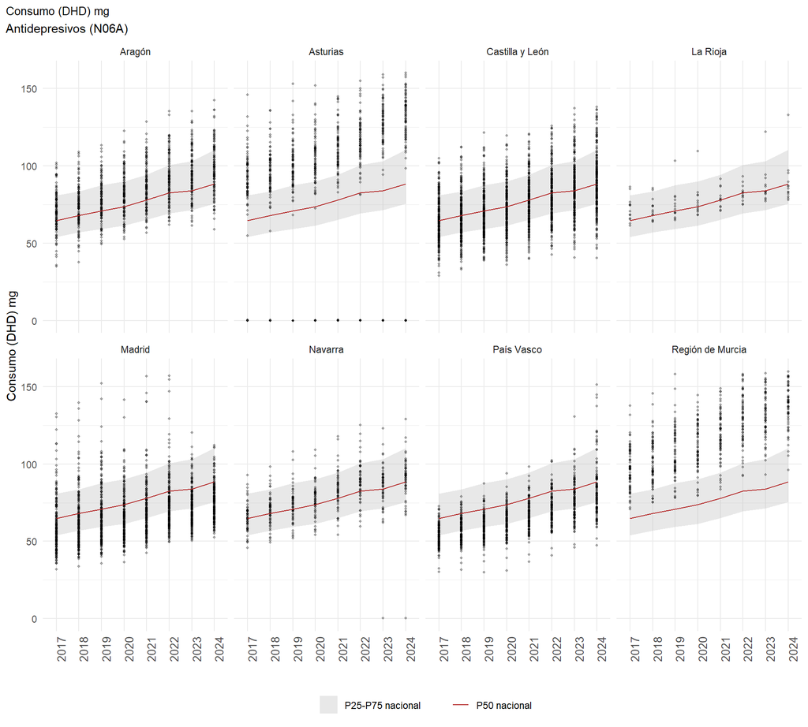

**Inhibidores no selectivos de recaptación de monoaminas (N06AA)**

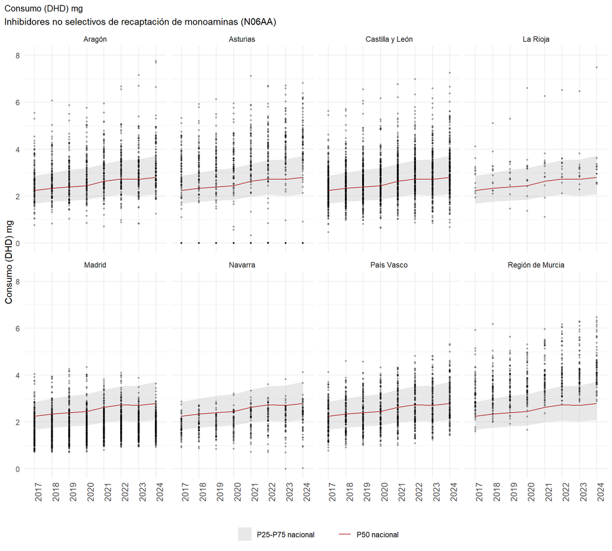

**Inhibidores selectivos de recaptación de serotonina (N06AB)**

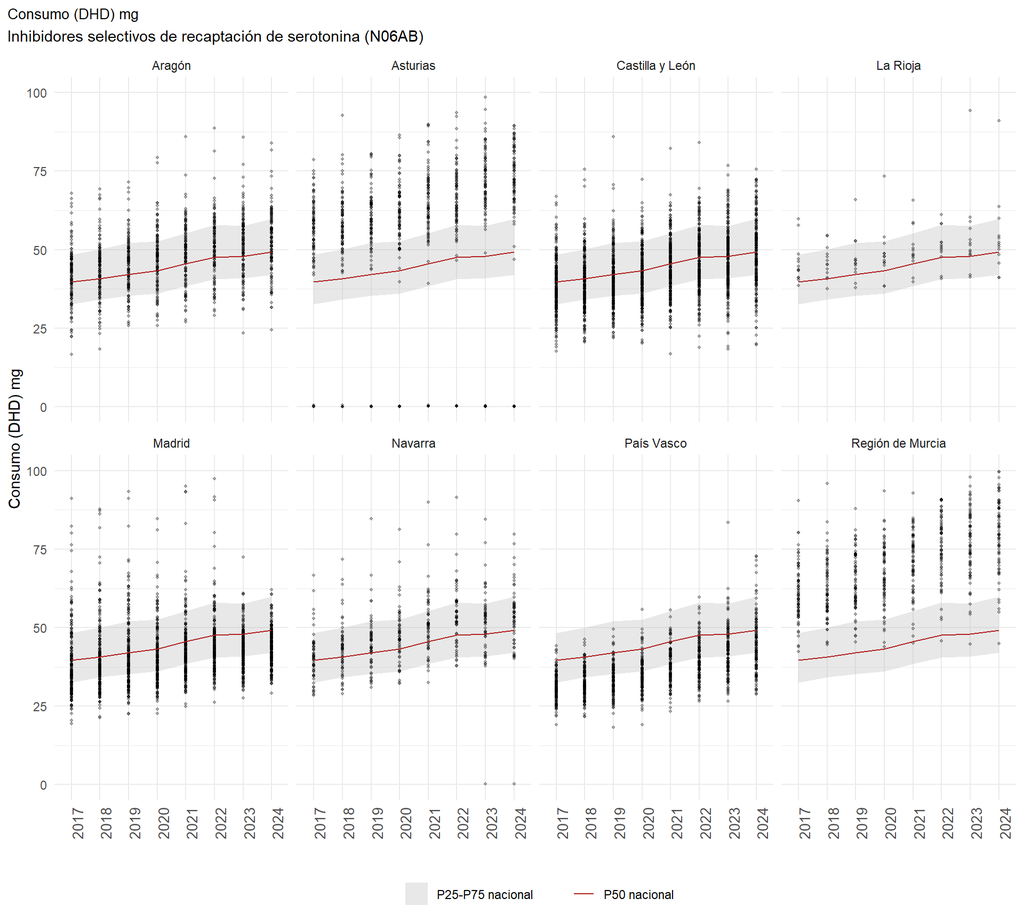

**Otros antidepresivos (N06AX)**

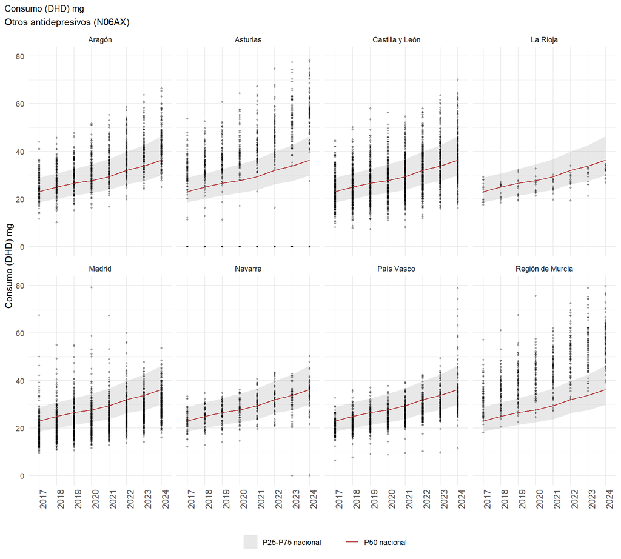

## Variación geográfica de consumo (DHD) de antidepresivos en el año 2024

**Descripción figura**

Se muestra la variación geográfica mediante mapas por CCAA del consumo (DHD) en las zonas básicas de salud que componen el sistema nacional de salud para el último año disponible. La figura está coloreada por quintiles calculados a nivel nacional.

**Antidepresivos (N06A)**

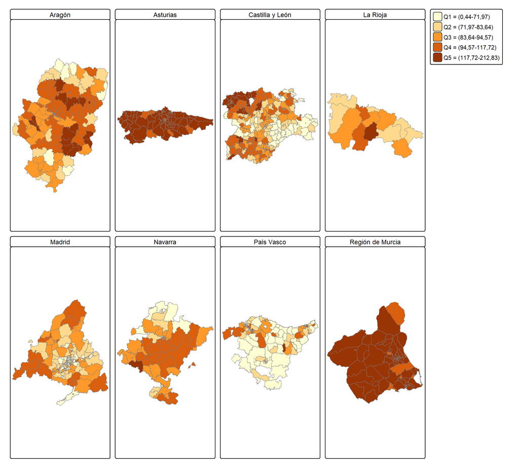

**Inhibidores no selectivos de recaptación de monoaminas (N06AA)**

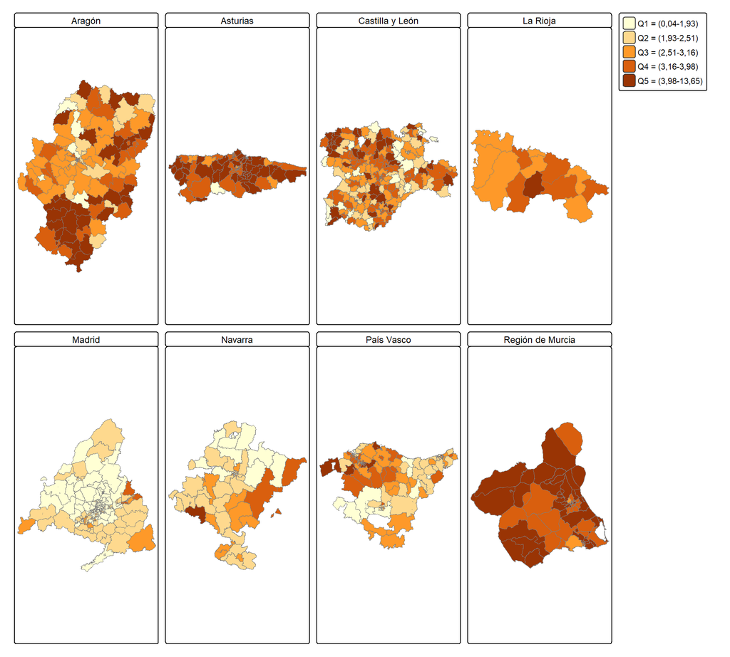

**Inhibidores selectivos de recaptación de serotonina (N06AB)**

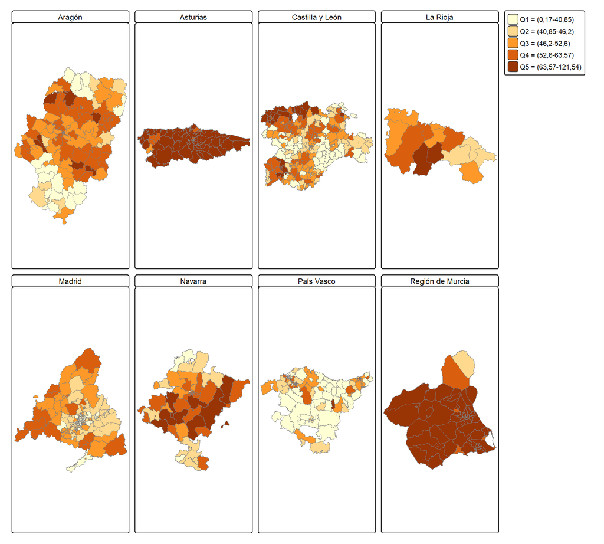

**Otros antidepresivos (N06AX)**

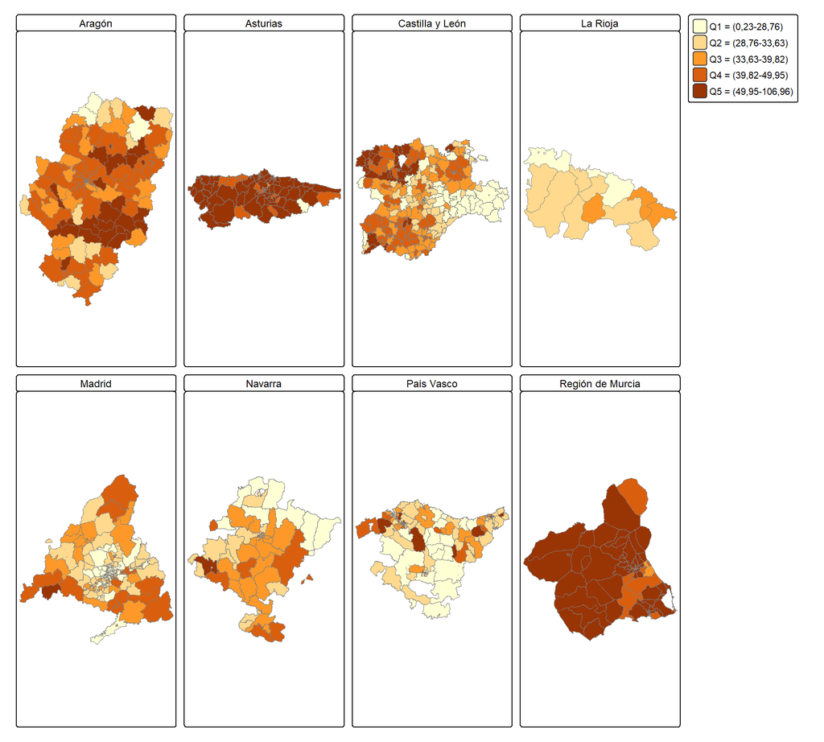

## Comparación de la variación de gasto (PVP) frente a variación de consumo (DHD)

**Descripción figura**

Se muestra el gasto PVP frente al consumo (DHD) donde para cada comunidad autónoma se calcula una regresión lineal en función de los valores calculados para cada ZBS para toda la serie temporal.

**Antidepresivos (N06A)**

[interactive chart not shown]

**Inhibidores no selectivos de recaptación de monoaminas (N06AA)**

[interactive chart not shown]

**Inhibidores selectivos de recaptación de serotonina (N06AB)**

[interactive chart not shown]

**Otros antidepresivos (N06AX)**

[interactive chart not shown]

# Notas metodológicas

## Sobre los resultados analizados

Este informe se centra en el cálculo de las tasas estandarizadas para cada subgrupo terapéutico tomando como referencia la población española (población INE), por sexo y grupo quinquenal de edad, para cada año del periodo de estudio. Este informe restringe el periodo de estudio desde el 01 de enero de 2017 al 31 de diciembre de 2024. Los indicadores de consumo de medicamentos están calculados como Dosis por mil Habitantes Día (DHD), o como gasto (€) por habitante, utilizando como referencia la Dosis Diaria Definida (DDD) por envase de cada medicamento o el Precio de Venta al Público (PVP) disponibles en el [nomenclator de facturación de farmacia del Ministerio de Sanidad](https://www.sanidad.gob.es/profesionales/nomenclator.do) (descargado en Septiembre 2025) respectivamente.

- El número de envases dispensados por habitante se calcula como el
  $$\sum(envases_{ATC, ZBS})/población_{ZBS, sexo, grupo edad}$$
- Dosis por mil Habitantes Día (DHD) se calcula como el
  $$((\sum(DDD_{ATC}) * 1000_{habitantes})/ (población_{ZBS, sexo, grupo edad} * 365_{días}))$$
- El gasto (€) por habitante se calcula como
  $$Gasto = \sum(PVP)/(población_{ZBS, sexo, grupo edad})$$

## Sobre la unidad de análisis

La unidad de análisis en este informe son las zonas básicas de salud (ZBS) de referencia según la residencia de los pacientes dispensados.

## Sobre los indicadores

Los indicadores estudiados se corresponden con subgrupos de antidepresivos en función de su código ATC, además de aquellos otros indicadores considerados relevantes para estudio por las comunidades autónomas participantes en este proyecto.

- Antidepresivos (*N06A*),
- Subgrupo terapéutico:
  - Inhibidores no selectivos de recaptación de monoaminas (*N06AA*),
  - Inhibidores selectivos de recaptación de serotonina (*N06AB*),
  - Otros antidepresivos (*N06AX*).

A continuación se muestra el listado de códigos de ATC que aparecen en los datos de entrada:

```
flowchart TD
    A[N06A] -->B[N06AA]
    A -->C[N06AB]
    A -->D[N06AX]
    B -->G[N06AA10\nN06AA09\nN06AA04\nN06AA02\nN06AA21\nN06AA12\nN06AA06]
    C -->H[N06AB10\nN06AB04\nN06AB06\nN06AB03\nN06AB08\nN06AB05]
    D -->I[N06AX11\nN06AX16\nN06AX23\nN06AX03\nN06AX18\nN06AX26\nN06AX05\nN06AX14\nN06AX21\nN06AX12\nN06AX22]
```

## Fuente de datos

Los registros de los envases dispensados han sido extraídos de acuerdo al modelo común de datos del Atlas de Farmacia a partir de la base de datos de dispensaciones (i.e., receta electrónica) o base de datos de facturación de farmacia (i.e., cinta de facturación de farmacia) de las CCAA participantes. Puede consultar el modelo común de datos en el [repositorio del proyecto](https://github.com/cienciadedatosysalud/atlas-farmacia).

## Sobre el numerador

Para el cálculo de los indicadores se utilizaron todos los envases dispensados de forma ambulatoria en oficina de farmacia de aquellos fármacos cuyo ATC se consideró relevante (i.e., antidepresivos (*N06A*)) a pacientes con una tarjeta sanitaria activa en el momento de la dispensación independientemente de la necesidad de visado y de la patología o condición para la que fueran dispensados. Estos ATC no incluyen todos los antidepresivos sino sólo aquellos seleccionados como relevantes para estudio.

| CCAA | Numerador | Fuente de información |
| --- | --- | --- |
| Aragón | Población residente en la CCAA y asignada a ZBS que tenga al menos una dispensación durante el periodo de estudio | Receta electrónica |
| Principado de Asturias | Población residente asignada a ZBS con al menos una dispensación | Receta electrónica |
| Castilla y León | Solo se incluyen recetas de pacientes de Castilla y León (tanto dentro como fuera de la CCAA si están prescritas en la CCAA) | Facturación farmacia ambulatoria |
| Comunidad de Madrid | Población residente asignada a ZBS con al menos una dispensación | Receta electrónica |
| Comunidad Foral de Navarra | Residentes en la CCAA adscritas a la ZBS (independientemente del profesional del SNS-O que la realiza) | Receta electrónica |
| País Vasco | Población TIS con tarjeta sanitaria adscrita a un ZBS de la CCAA | Receta electrónica |
| La Rioja | Sólo residentes en la CCAA con tarjeta sanitaria adscrita a una ZBS de la CCAA | Receta electrónica |
| Región de Murcia | Población residente asignada a ZBS con al menos una dispensación | Receta electrónica |

## Sobre el denominador

Los envases dispensados se asignan a la ZBS relativa al área de residencia del paciente. De esta manera, el análisis realizado compara el consumo farmacéutico o la exposición de las poblaciones a estos fármacos según su lugar de residencia. La población utilizada en la estandarización y cálculo de los denominadores de los indicadores procede de la actualización anual de población con tarjeta sanitaria del conjunto de todas las CCAA durante el periodo de estudio.

## Sobre la metodología de análisis

Este informe se basa en la compilación y meta-análisis de resultados agregados generados por cada CCAA participante de forma federada, mediante la ejecución de análisis locales reproducibles. Este informe es el primer AtlasVPM realizado de forma federada. Las CCAA han participado en este AtlasVPM desplegando un entorno analítico reproducible (i.e., contendor Docker) conteniendo los análisis estadísticos locales para la generación de resultados agregados y compartiendo estos resultados con el grupo de Ciencia de Datos para la Investigación en Servicios y Políticas de Salud en el Instituto Aragonés de Ciencias de la Salud (IACS).

# Contribuciones

[figure not shown]

Aragón

Francisco Estupiñán Romero, Javier González Galindo, Santiago Royo Sierra, Natalia Martínez Lizaga, Miriam Seral Rodríguez, Ramón Launa Garcés, Ester Angulo Pueyo, Manolo Ridao López, Enrique Bernal Delgado

Instituto Aragonés de Ciencias de Salud

[figure not shown]

Principado de Asturias

Gracia M Modroño Riaño

Servicio de Salud del Principado de Asturias

[figure not shown]

Islas Baleares

Eusebi Castaño Riera, María Zaforteza Dezcallar, María Jesús Martín Sánchez

Consejería de Salud y Consumo

[figure not shown]

Cantabria

María Ángeles Lumbreras, Flora Pérez Hernández, Óscar Valcuende Mantilla

Dirección General de Ordenación Sanitaria, Farmacia e Inspección

[figure not shown]

Cataluña

Cristina Colls Guerra, Mireia Espallargues Carreras, Érica Martínez Solanas, Manuel Medina Peralta, Andrea Molina Nadal, Pere Carbonell Puigdollers, Montserrat Vicente Belis

Agència de Qualitat i Avaluació Sanitàries de Catalunya (AQUAS). Servei Català de la Salut. Consorci Sanitari de Barcelona

[figure not shown]